# Angle Learning Comprehension

Freya Watkins

2019-06-26

## Angle Learning comprehension analysis

Setup markdown file & load packages:

```r
knitr::opts_chunk$set(warning = TRUE, message = FALSE)
library(tidyverse)
library(car)
library(lme4)
library(afex)
library(emmeans)
library(directlabels)
```

Read in data file. Convert Session & Subject variables are factors:

```r
angleLearn <- read_csv("2019-06-25 AngleLearningData.csv")
head(angleLearn)
```

```
## # A tibble: 6 x 31
##   Version Subject Session BlockOrder Trial Angle BlockNo Icon   Item Pair
##   <chr>     <dbl>   <dbl>      <dbl> <dbl> <chr> <chr>   <chr> <dbl> <chr>
## 1 V2          320       2          2    15 45L   1b      1.56     50 0-90
## 2 V1          101       2          4    67 45L   1b      3.9      71 0-0
## 3 V3          107       2          5    98 45L   1d      3.02     76 0-90
## 4 V1          204       1          4    55 45L   1a      1.39     51 0-90
## 5 V1          401       1          4    57 45L   1d      na       59 90-90
## 6 V2          407       2          4    63 45L   1b      4.75     81 0-0
## # ... with 21 more variables: Condition <chr>, Sign <chr>, Type <chr>,
## #   ACC <dbl>, Error <dbl>, S1corr <dbl>, RT <dbl>, ChronTrial <dbl>,
## #   Filename <chr>, ChronRT <dbl>, RTdiff <dbl>, Length <dbl>,
## #   ExclItem <dbl>, ExclNoTrig <dbl>, ExclEarlyTrig <dbl>,
## #   ExclIncorr <dbl>, ExclSlow <dbl>, ExclPpt <dbl>, PptSlowFast <dbl>,
## #   BadMic <dbl>, NewExclSlowFast <dbl>
```

```r
angleLearn$Session <- as.factor(angleLearn$Session)
angleLearn$Condition <- as.factor(angleLearn$Condition)
angleLearn$Version <- as.factor(angleLearn$Version)
angleLearn$Type <- as.factor(angleLearn$Type)
angleLearn$Subject <- as.factor(angleLearn$Subject)
```

Check number of subjects and how many data points per subject:

```r
length(unique(angleLearn$Subject))
```

```
## [1] 60
```

```r
summary(angleLearn$Subject)
```

```
## 101 102 103 104 105 106 107 108 109 110 201 202 203 204 205 206 207 208
## 192 192 192 192 192 192 192 192 192 192 192 192 192 192 192 192 192 192
## 209 210 211 212 213 214 215 216 217 218 219 220 221 301 302 304 305 306
## 192 192 192 192 192 192 192 192 192 192 192 192 192 192 192 192 192 192
## 307 309 310 311 312 313 314 315 316 317 318 319 320 321 401 402 403 404
## 192 192 192 192 192 192 192 192 192 192 192 192 192 192 192 192 192 192
## 405 406 407 408 409 410
## 192 192 192 192 192 192
```

60 subjects total. Each subject saw 192 trials across both sessions (96 per session). 6 practice trials (3 per session) have already been excluded from data. No NA values.

Check distribution of experiment versions, and how many times each sign was seen in each of the three learning conditions:

```r
table(angleLearn$Subject, angleLearn$Version)
```

```
##
##        V1  V2  V3
##   101 192   0   0
##   102 192   0   0
##   103 192   0   0
##   104 192   0   0
##   105 192   0   0
##   106   0   0 192
##   107   0   0 192
##   108   0   0 192
##   109   0   0 192
##   110   0   0 192
##   201 192   0   0
##   202 192   0   0
##   203 192   0   0
```

[output cut: 47 more lines]

```r
table(angleLearn$Sign, angleLearn$Condition)
```

```
##
##              both front side
##   ALARM        38    40   42
##   ANIMAL       38    40   42
##   BABY         38    40   42
##   BADMINTON    42    38   40
##   BANDAGE      42    38   40
##   BANK         40    42   38
##   BEANS        42    38   40
##   BED          38    40   42
##   BEEF         42    38   40
##   BELT         40    42   38
##   BISCUIT      38    40   42
##   BOTTLE       38    40   42
##   BOWL         42    38   40
##   BOX          38    40   42
##   BREAD        42    38   40
##   BROOM        40    42   38
##   BROTHER      38    40   42
##   BUS          38    40   42
##   BUTTER       40    42   38
##   CABBAGE      40    42   38
##   CAKE         42    38   40
##   CAR          40    42   38
##   CHILDREN     38    40   42
##   COWBOY       40    42   38
##   CROCODILE    42    38   40
##   DOCTOR       38    40   42
##   DOOR         38    40   42
##   DRILL        40    42   38
##   ELEPHANT     40    42   38
##   FAMILY       40    42   38
##   FATHER       40    42   38
##   FISH         42    38   40
##   FLAG         42    38   40
##   FLOOR        42    38   40
##   FRIEND       42    38   40
##   FROG         38    40   42
##   GARDEN       40    42   38
##   GRAPES       40    42   38
```

[output cut: 43 more lines]

```
##   THEATRE      38    40   42
##   TIME         38    40   42
##   TOILET       40    42   38
##   TOMATO       42    38   40
##   TOMORROW     38    40   42
##   TOWEL        38    40   42
##   TRAFFIC      42    38   40
##   TRAIN        40    42   38
##   TREE         40    42   38
##   UMBRELLA     38    40   42
##   VIOLIN       40    42   38
##   WALL         42    38   40
##   WAR          40    42   38
##   WEEK         40    42   38
##   WINDOW       42    38   40
```

20 participants did Version 1; 19 did version 2 & 21 did version 3.

Number of unique signs:

```r
length(unique(angleLearn$Sign))
```

```
## [1] 96
```

Check number of data points per sign:

```r
table(angleLearn$Sign)
```

```
##
##      ALARM     ANIMAL       BABY  BADMINTON    BANDAGE       BANK
##        120        120        120        120        120        120
##      BEANS        BED       BEEF       BELT    BISCUIT     BOTTLE
##        120        120        120        120        120        120
##       BOWL        BOX      BREAD      BROOM    BROTHER        BUS
##        120        120        120        120        120        120
##     BUTTER    CABBAGE       CAKE        CAR   CHILDREN     COWBOY
##        120        120        120        120        120        120
##  CROCODILE     DOCTOR       DOOR      DRILL   ELEPHANT     FAMILY
##        120        120        120        120        120        120
##     FATHER       FISH       FLAG      FLOOR     FRIEND       FROG
##        120        120        120        120        120        120
##     GARDEN     GRAPES      GRASS     HAMMER HELICOPTER      HORSE
##        120        120        120        120        120        120
##  INJECTION     JUMPER    LIGHTER      MATCH       MEAT   MECHANIC
##        120        120        120        120        120        120
##   MEDICINE       MILK      MONEY     MONKEY    MORNING  MOTORBIKE
##        120        120        120        120        120        120
##   MOUNTAIN       NAME    PARENTS       PEAS     PENCIL    PERFUME
##        120        120        120        120        120        120
##     PERSON      PIZZA      PLANE     POLICE        PUB     RABBIT
##        120        120        120        120        120        120
##       RAKE      RIVER       ROAD      ROBOT       ROOM      SALAD
##        120        120        120        120        120        120
##   SANDWICH   SCISSORS     SHORTS     SHOWER  SPAGHETTI     STAIRS
##        120        120        120        120        120        120
##  SUBTITLES      SUGAR        SUN    THEATRE       TIME     TOILET
##        120        120        120        120        120        120
##     TOMATO   TOMORROW      TOWEL    TRAFFIC      TRAIN       TREE
##        120        120        120        120        120        120
##   UMBRELLA     VIOLIN       WALL        WAR       WEEK     WINDOW
##        120        120        120        120        120        120
```

There are 96 signs overall. Each one was tested 120 times overall (60 participants at session 1; same 60 participants at session 2)

Any signs without 120 data points per subject?

```r
which(table(angleLearn$Sign) != 120)
```

```
## named integer(0)
```

No

# Accuracy analysis

1. Check item accuracy:

First calculate accuracy per item and per session:

```r
item_acc_S1 <- filter(angleLearn, Session == 1) %>% group_by(Sign) %>% summarize(ACC = mean(ACC))
item_acc_S1
```

```
## # A tibble: 96 x 2
##    Sign        ACC
##    <chr>     <dbl>
##  1 ALARM     0.633
##  2 ANIMAL    0.967
##  3 BABY      1
##  4 BADMINTON 0.95
##  5 BANDAGE   0.983
##  6 BANK      0.533
##  7 BEANS     0.533
##  8 BED       1
##  9 BEEF      0.633
## 10 BELT      1
## # ... with 86 more rows
```

```r
item_acc_S2 <- filter(angleLearn, Session == 2) %>% group_by(Sign) %>% summarize(ACC = mean(ACC))
item_acc_S2
```

```
## # A tibble: 96 x 2
##    Sign        ACC
##    <chr>     <dbl>
##  1 ALARM     0.217
##  2 ANIMAL    0.783
##  3 BABY      1
##  4 BADMINTON 0.867
##  5 BANDAGE   0.9
##  6 BANK      0.35
##  7 BEANS     0.15
##  8 BED       0.617
##  9 BEEF      0.433
## 10 BELT      1
## # ... with 86 more rows
```

Which items had below 60% accuracy (per session)?

```r
item_acc_S1[(item_acc_S1[,2] <0.6),]
```

```
## # A tibble: 4 x 2
##   Sign     ACC
##   <chr>  <dbl>
## 1 BANK   0.533
## 2 BEANS  0.533
## 3 CAR    0.583
## 4 FATHER 0.483
```

```r
item_acc_S2[(item_acc_S2[,2] <0.6),]
```

```
## # A tibble: 29 x 2
##    Sign      ACC
##    <chr>   <dbl>
##  1 ALARM   0.217
##  2 BANK    0.35
##  3 BEANS   0.15
##  4 BEEF    0.433
##  5 BROTHER 0.4
##  6 CABBAGE 0.367
##  7 CAKE    0.583
##  8 CAR     0.317
##  9 DOCTOR  0.4
## 10 DRILL   0.4
## # ... with 19 more rows
```

4 items had <60% accuracy at Session 1 (4% total items). 29 items had <60% accuracy at Session 2 (30% total items)

No items excluded yet. Preliminary analysis excluded items with <60% accuracy at Session 1

2. Check participant accuracy:

First calculate accuracy per participant and per session:

```r
ppt_acc_S1 <- filter(angleLearn, Session == 1) %>% group_by(Subject) %>%
     summarize(ACC = mean(ACC))
ppt_acc_S1
```

```
## # A tibble: 60 x 2
##    Subject   ACC
##    <fct>   <dbl>
##  1 101     0.885
##  2 102     0.927
##  3 103     0.958
##  4 104     0.896
##  5 105     0.885
##  6 106     0.958
##  7 107     0.729
##  8 108     0.938
##  9 109     0.854
## 10 110     0.781
## # ... with 50 more rows
```

```r
ppt_acc_S2 <- filter(angleLearn, Session == 2) %>% group_by(Subject) %>%
     summarize(ACC = mean(ACC))
ppt_acc_S2
```

```
## # A tibble: 60 x 2
##    Subject   ACC
##    <fct>   <dbl>
##  1 101     0.833
##  2 102     0.781
##  3 103     0.635
##  4 104     0.552
##  5 105     0.698
##  6 106     0.896
##  7 107     0.552
##  8 108     0.812
##  9 109     0.646
## 10 110     0.656
## # ... with 50 more rows
```

Which participants had below 60% accuracy (per session)?

```r
ppt_acc_S1[(ppt_acc_S1[,2] <0.6),]
```

```
## # A tibble: 1 x 2
##   Subject   ACC
##   <fct>   <dbl>
## 1 320     0.490
```

```r
ppt_acc_S2[(ppt_acc_S2[,2] <0.6),]
```

```
## # A tibble: 15 x 2
##    Subject   ACC
##    <fct>   <dbl>
##  1 104     0.552
##  2 107     0.552
##  3 204     0.448
##  4 207     0.479
##  5 208     0.583
##  6 209     0.333
##  7 215     0.469
##  8 219     0.562
##  9 301     0.479
## 10 306     0.490
## 11 310     0.583
## 12 314     0.458
## 13 319     0.594
## 14 320     0.417
## 15 402     0.510
```

1 participant had less than 60% accuracy at Session 1. 15 participants had less than 60% accuracy at Session 2

No participants excluded yet. Preliminary analysis excluded participants with <70% accuracy at Session 1

Calculate accuracy averages by condition and session:

```r
angleLearn %>% group_by(Condition, Session) %>%
  summarize(ACC = mean(ACC))
```

```
## # A tibble: 6 x 3
## # Groups:   Condition [3]
##   Condition Session   ACC
##   <fct>     <fct>   <dbl>
## 1 both      1       0.884
## 2 both      2       0.696
## 3 front     1       0.881
## 4 front     2       0.678
## 5 side      1       0.858
## 6 side      2       0.680
```

Looks like no significant differences in accuracy across conditions at either session. Side is worst at Session 1, Front is worst as Session 2. Overall accuacy drops ~18-20% between S1 and S2.

Plot Accuracy data:

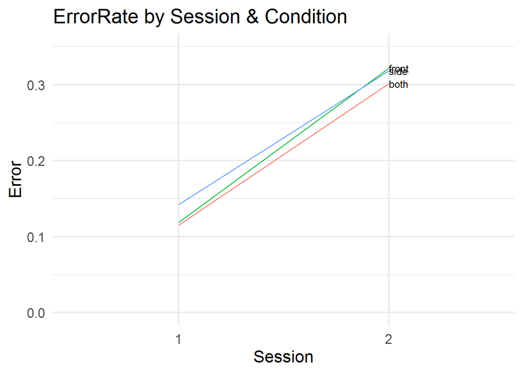

```r
angleLearn %>% group_by(Session, Condition) %>%
  summarize(Error = mean(Error)) %>%
  ggplot + geom_line(aes(x = Session, y = Error, group = Condition,
                         colour = Condition)) +
  coord_cartesian(ylim = c(0,0.35)) +
  geom_dl(aes(x = Session, y = Error, label = Condition), method = list(dl.combine("last.points"), cex = 0.8)) +
  theme_minimal(base_size = 16) +
  theme(legend.position = "none") +
  ggtitle('ErrorRate by Session & Condition')
```

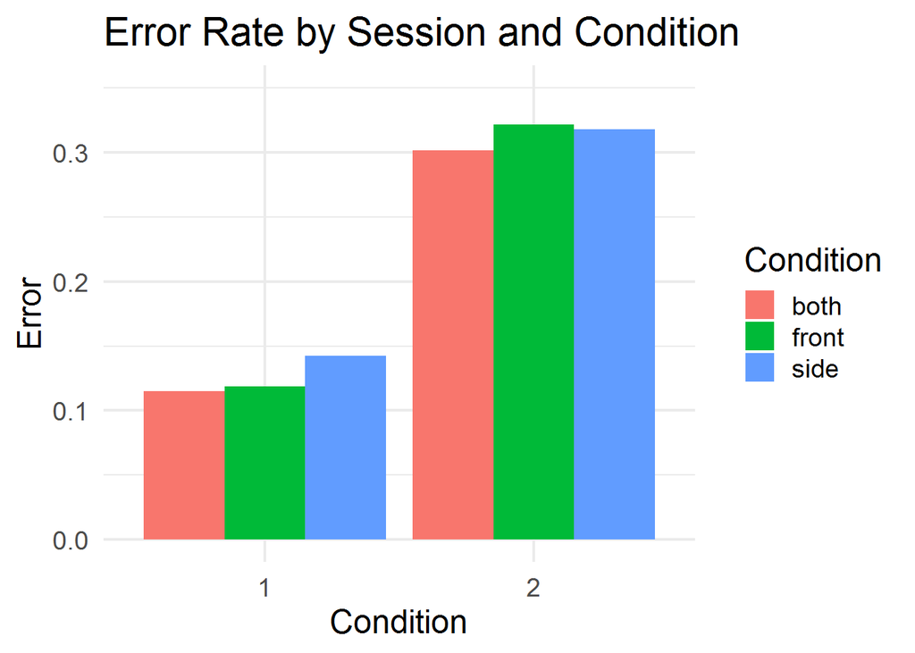

```r
angleLearn %>% group_by(Session, Condition) %>%
  summarize(Error = mean(Error)) %>%
  ggplot(aes(x = factor(Session, level = c("1", "2")),
             y = Error, fill = Condition)) +
  geom_bar(stat = 'identity', position = position_dodge()) +
  coord_cartesian(ylim = c(0, 0.35)) +
  theme_minimal(base_size = 18) +
  ggtitle('Error Rate by Session and Condition') + xlab('Condition')
```

Run linear model on accuracy data:

```r
lmer.ACC <- mixed(ACC ~ Condition*Session + (1 | Subject) +
                    (1 + Condition|Sign),
                  angleLearn, all_fit = TRUE, method = "LRT",
                  control = lmerControl(optCtrl = list(maxfun = 1e6)))
```

```
## Fitting 4 (g)lmer() models:
## [
```

```
## .
```

```
## .
```

```
## .
```

```
## .]
```

```r
lmer.ACC
```

```
## Mixed Model Anova Table (Type 3 tests, LRT-method)
##
## Model: ACC ~ Condition * Session + (1 | Subject) + (1 + Condition |
## Model:     Sign)
## Data: angleLearn
## Df full model: 14
##              Effect df      Chisq p.value
## 1         Condition  2     4.93 +     .08
## 2           Session  1 821.58 ***  <.0001
## 3 Condition:Session  2       2.59     .27
## ---
## Signif. codes:  0 '***' 0.001 '**' 0.01 '*' 0.05 '+' 0.1 ' ' 1
```

# RT analysis

1. Exclude any inaccurate trials:

```r
angleLearnRT <- filter(angleLearn,
             ACC == 1)
angleLearnRT
```

```
## # A tibble: 8,981 x 31
##    Version Subject Session BlockOrder Trial Angle BlockNo Icon   Item Pair
##    <fct>   <fct>   <fct>        <dbl> <dbl> <chr> <chr>   <chr> <dbl> <chr>
##  1 V2      320     2                2    15 45L   1b      1.56     50 0-90
##  2 V3      107     2                5    98 45L   1d      3.02     76 0-90
##  3 V1      204     1                4    55 45L   1a      1.39     51 0-90
##  4 V1      401     1                4    57 45L   1d      na       59 90-90
##  5 V2      407     2                4    63 45L   1b      4.75     81 0-0
##  6 V3      311     2                5    99 45L   1a      1.71     44 90-90
##  7 V3      211     2                4    63 45L   1c      1.39     51 0-0
##  8 V1      305     2                2    27 45L   1a      5.9      25 0-90
##  9 V2      405     2                3    48 45L   1d      2.87     54 90-90
## 10 V1      203     2                3    33 45L   1b      4.33     75 0-90
## # ... with 8,971 more rows, and 21 more variables: Condition <fct>,
## #   Sign <chr>, Type <fct>, ACC <dbl>, Error <dbl>, S1corr <dbl>,
## #   RT <dbl>, ChronTrial <dbl>, Filename <chr>, ChronRT <dbl>,
## #   RTdiff <dbl>, Length <dbl>, ExclItem <dbl>, ExclNoTrig <dbl>,
## #   ExclEarlyTrig <dbl>, ExclIncorr <dbl>, ExclSlow <dbl>, ExclPpt <dbl>,
## #   PptSlowFast <dbl>, BadMic <dbl>, NewExclSlowFast <dbl>
```

2,539/11,520 (22%) trials were incorrect and thus removed for the RT analysis.

2. Exclude any trials +/- 2 SD from session mean

```r
# angleLearnRT <- filter(angleLearnRT,
#              NewExclSlowFast != 1)
# table(angleLearnRT$Subject)
```

Haven’t done this for now

3. Are any participants particularly fast or slow? (M +/- 2SD)

First calculate mean RT per participant per session:

```r
# ppt_meanRT <- angleLearnRT %>% group_by(Subject, Session) %>%
#     summarize(RT = mean(RT))
# ppt_sdRT <- angleLearnRT %>% group_by(Subject, Session) %>%
#     summarize(sd = sd(RT))
# print(ppt_meanRT)
# print(ppt_sdRT)
```

Then compare to session mean RT +/- 2 SD :

```r
# meanRT <- mean(angleLearn$RT) # needs to be per session though
# meanRT
# sdRT <- sd(angleLearn$RT)
# sdRT
# sdRT*2
# meanRT + sdRT*2
# meanRT - sdRT*2
```

Again haven’t done any exclusions here yet

4. Were any items particularly fast or slow?

```r
# item_RT <- angleLearnRT %>% group_by(Sign) %>%
#      summarize(RT = mean(RT))
# print(item_RT)
```

Again haven’t excluded anything here

Calculate RT averages by Condition and Session:

```r
angleLearnRT %>% group_by(Condition, Session) %>%
  summarize(ChronRT = mean(ChronRT))
```

```
## # A tibble: 6 x 3
## # Groups:   Condition [3]
##   Condition Session ChronRT
##   <fct>     <fct>     <dbl>
## 1 both      1         1878.
## 2 both      2         2218.
## 3 front     1         1894.
## 4 front     2         2196.
## 5 side      1         1908.
## 6 side      2         2199.
```

At Session 1, Both angles condition is 30ms faster than Side-only condition At Sessopm 2, Both angles condition is around 15-20ms slower than Front-only & Side-only Slowdown of 290-340ms between session 1 and session 2.

Plot RT data:

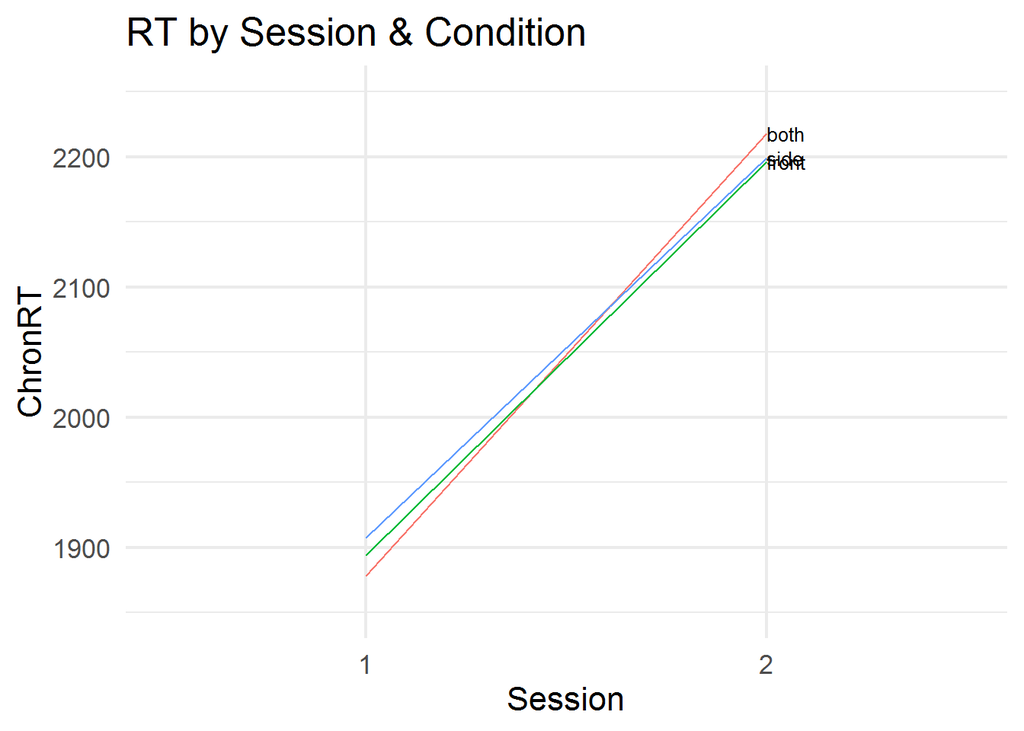

```r
angleLearnRT %>% group_by(Session, Condition) %>%
  summarize(ChronRT = mean(ChronRT)) %>%
  ggplot + geom_line(aes(x = Session, y = ChronRT, group = Condition,
                         colour = Condition)) +
  coord_cartesian(ylim = c(1850,2250)) +
  geom_dl(aes(x = Session, y = ChronRT, label = Condition),
          method = list(dl.combine("last.points"), cex = 0.8)) +
  theme_minimal(base_size = 16) +
  theme(legend.position = "none") +
  ggtitle('RT by Session & Condition')
```

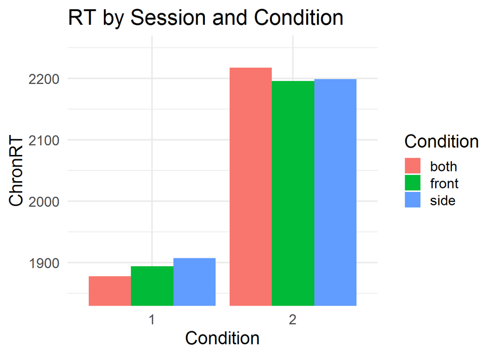

```r
angleLearnRT %>% group_by(Session, Condition) %>%
  summarize(ChronRT = mean(ChronRT)) %>%
  ggplot(aes(x = factor(Session, level = c("1", "2")),
             y = ChronRT, fill = Condition)) +
  geom_bar(stat = 'identity', position = position_dodge()) +
  coord_cartesian(ylim = c(1850, 2250)) +
  theme_minimal(base_size = 18) +
  ggtitle('RT by Session and Condition') + xlab('Condition')
```

Linear model for RT:

```r
lmer.RT <- mixed(ChronRT ~ Condition*Session + (1 | Subject) +
                   (1 + Condition|Sign),
                 angleLearnRT, all_fit = TRUE, method = "LRT",
                 control = lmerControl(optCtrl = list(maxfun = 1e6)))
```

```
## Fitting 4 (g)lmer() models:
## [
```

```
## ..
```

```
## ..]
```

```r
lmer.RT
```

```
## Mixed Model Anova Table (Type 3 tests, LRT-method)
##
## Model: ChronRT ~ Condition * Session + (1 | Subject) + (1 + Condition |
## Model:     Sign)
## Data: angleLearnRT
## Df full model: 14
##              Effect df       Chisq p.value
## 1         Condition  2        1.67     .43
## 2           Session  1 1491.29 ***  <.0001
## 3 Condition:Session  2      6.17 *     .05
## ---
## Signif. codes:  0 '***' 0.001 '**' 0.01 '*' 0.05 '+' 0.1 ' ' 1
```

```r
anova(lmer.RT)
```

```
## Mixed Model Anova Table (Type 3 tests, LRT-method)
##
## Model: ChronRT ~ Condition * Session + (1 | Subject) + (1 + Condition |
## Model:     Sign)
## Data: angleLearnRT
## Df full model: 14
##                   Df     Chisq Chi Df Pr(>Chisq)
## Condition         12    1.6659      2     0.4348
## Session           13 1491.2944      1     <2e-16 ***
## Condition:Session 12    6.1715      2     0.0457 *
## ---
## Signif. codes:  0 '***' 0.001 '**' 0.01 '*' 0.05 '.' 0.1 ' ' 1
```

Pairwise analysis of conditions at session 1 and session 2:

```r
emm1 <- emmeans(lmer.RT, specs = ~ Session:Condition, data = angleLearnRT)
Both1 <- c(1, 0, 0, 0, 0, 0)
Side1 <- c(0, 0, 0, 0, 1, 0)
Front1 <- c(0, 0, 1, 0, 0, 0)
contrast(emm1, method = list("Both1 - Side1" = Both1 - Side1,
                             "Both1 - Front1" = Both1 - Front1,
                             "Side1 - Front1" = Side1 - Front1) )
```

```
##  contrast       estimate   SE  df z.ratio p.value
##  Both1 - Side1     -41.2 15.6 Inf -2.640  0.0083
##  Both1 - Front1    -18.4 15.2 Inf -1.208  0.2271
##  Side1 - Front1     22.8 15.9 Inf  1.440  0.1498
```

```r
Both2 <- c(0, 1, 0, 0, 0, 0)
Side2 <- c(0, 0, 0, 0, 0, 1)
Front2 <- c(0, 0, 0, 1, 0, 0)
contrast(emm1, method = list("Both2 - Side2" = Both2 - Side2,
                             "Both2 - Front2" = Both2 - Front2,
                             "Side2 - Front2" = Side2 - Front2) )
```

```
##  contrast       estimate   SE  df z.ratio p.value
##  Both2 - Side2     10.46 17.3 Inf 0.605   0.5452
##  Both2 - Front2    15.39 17.0 Inf 0.904   0.3659
##  Side2 - Front2     4.93 17.6 Inf 0.279   0.7799
```

Log-transform reaction times:

```r
angleLearnRT <- mutate(angleLearnRT, Log10RT = log10(ChronRT))
```

Log-transformed RT linear model:

```r
lmer.logRT <- mixed(Log10RT ~ Condition*Session + (1 | Subject) +
                   (1 + Condition|Sign),
                 angleLearnRT, all_fit = TRUE, method = "LRT",
                 control = lmerControl(optCtrl = list(maxfun = 1e6)))
```

```
## Fitting 4 (g)lmer() models:
## [..
```

```
## ..]
```

```r
lmer.logRT
```

```
## Mixed Model Anova Table (Type 3 tests, LRT-method)
##
## Model: Log10RT ~ Condition * Session + (1 | Subject) + (1 + Condition |
## Model:     Sign)
## Data: angleLearnRT
## Df full model: 14
##              Effect df       Chisq p.value
## 1         Condition  2        2.27     .32
## 2           Session  1 1687.68 ***  <.0001
## 3 Condition:Session  2      6.04 *     .05
## ---
## Signif. codes:  0 '***' 0.001 '**' 0.01 '*' 0.05 '+' 0.1 ' ' 1
```

```r
anova(lmer.logRT)
```

```
## Mixed Model Anova Table (Type 3 tests, LRT-method)
##
## Model: Log10RT ~ Condition * Session + (1 | Subject) + (1 + Condition |
## Model:     Sign)
## Data: angleLearnRT
## Df full model: 14
##                   Df     Chisq Chi Df Pr(>Chisq)
## Condition         12    2.2713      2    0.32121
## Session           13 1687.6774      1    < 2e-16 ***
## Condition:Session 12    6.0422      2    0.04875 *
## ---
## Signif. codes:  0 '***' 0.001 '**' 0.01 '*' 0.05 '.' 0.1 ' ' 1
```

LogRT pairwise analysis of conditions at session 1 and session 2:

```r
emm2 <- emmeans(lmer.logRT, specs = ~ Session:Condition, data = angleLearnRT)

Both1 <- c(1, 0, 0, 0, 0, 0)
Side1 <- c(0, 0, 0, 0, 1, 0)
Front1 <- c(0, 0, 1, 0, 0, 0)
contrast(emm2, method = list("Both1 - Side1" = Both1 - Side1,
                              "Both1 - Front1" = Both1 - Front1,
                              "Side1 - Front1" = Side1 - Front1) )
```

```
##  contrast       estimate      SE  df z.ratio p.value
##  Both1 - Side1  -0.00877 0.00308 Inf -2.842  0.0045
##  Both1 - Front1 -0.00405 0.00296 Inf -1.369  0.1709
##  Side1 - Front1  0.00472 0.00316 Inf  1.491  0.1359
```

```r
Both2 <- c(0, 1, 0, 0, 0, 0)
Side2 <- c(0, 0, 0, 0, 0, 1)
Front2 <- c(0, 0, 0, 1, 0, 0)
contrast(emm2, method = list("Both2 - Side2" = Both2 - Side2,
                              "Both2 - Front2" = Both2 - Front2,
                              "Side2 - Front2" = Side2 - Front2) )
```

```
##  contrast       estimate      SE  df z.ratio p.value
##  Both2 - Side2   0.00131 0.00342 Inf 0.383   0.7019
##  Both2 - Front2  0.00249 0.00332 Inf 0.750   0.4532
##  Side2 - Front2  0.00118 0.00351 Inf 0.337   0.7362
```